# Project : Investigate a TMDb Movie Dataset

### Now i have 16 columns only

I have to check null value in the dataset.

```python
df_imdb.isna().sum()
```

```
id                         0
popularity                 0
budget                     0
revenue                    0
original_title             0
cast                      76
director                  44
runtime                    0
genres                    23
production_companies    1030
release_date               0
vote_count                 0
vote_average               0
release_year               0
budget_adj                 0
revenue_adj                0
dtype: int64
```

```python
df_imdb.head(80)
```

|  | id | popularity | budget | revenue | original_title | cast | director | runtime | genres | production_companies | release_date | vote_count | vote_average | release_year | budget_adj | revenue_adj |
| --- | --- | --- | --- | --- | --- | --- | --- | --- | --- | --- | --- | --- | --- | --- | --- | --- |
| 0 | 135397 | 32.985763 | 150000000 | 1513528810 | Jurassic World | Chris Pratt\|Bryce Dallas Howard\|Irrfan Khan\|Vi... | Colin Trevorrow | 124 | Action\|Adventure\|Science Fiction\|Thriller | Universal Studios\|Amblin Entertainment\|Legenda... | 06-09-2015 | 5562 | 6.5 | 2015 | 1.379999e+08 | 1.392446e+09 |
| 1 | 76341 | 28.419936 | 150000000 | 378436354 | Mad Max: Fury Road | Tom Hardy\|Charlize Theron\|Hugh Keays-Byrne\|Nic... | George Miller | 120 | Action\|Adventure\|Science Fiction\|Thriller | Village Roadshow Pictures\|Kennedy Miller Produ... | 5/13/15 | 6185 | 7.1 | 2015 | 1.379999e+08 | 3.481613e+08 |
| 2 | 262500 | 13.112507 | 110000000 | 295238201 | Insurgent | Shailene Woodley\|Theo James\|Kate Winslet\|Ansel... | Robert Schwentke | 119 | Adventure\|Science Fiction\|Thriller | Summit Entertainment\|Mandeville Films\|Red Wago... | 3/18/15 | 2480 | 6.3 | 2015 | 1.012000e+08 | 2.716190e+08 |
| 3 | 140607 | 11.173104 | 200000000 | 2068178225 | Star Wars: The Force Awakens | Harrison Ford\|Mark Hamill\|Carrie Fisher\|Adam D... | J.J. Abrams | 136 | Action\|Adventure\|Science Fiction\|Fantasy | Lucasfilm\|Truenorth Productions\|Bad Robot | 12/15/15 | 5292 | 7.5 | 2015 | 1.839999e+08 | 1.902723e+09 |
| 4 | 168259 | 9.335014 | 190000000 | 1506249360 | Furious 7 | Vin Diesel\|Paul Walker\|Jason Statham\|Michelle ... | James Wan | 137 | Action\|Crime\|Thriller | Universal Pictures\|Original Film\|Media Rights ... | 04-01-2015 | 2947 | 7.3 | 2015 | 1.747999e+08 | 1.385749e+09 |
| ... | ... | ... | ... | ... | ... | ... | ... | ... | ... | ... | ... | ... | ... | ... | ... | ... |
| 75 | 308369 | 2.141506 | 0 | 0 | Me and Earl and the Dying Girl | Thomas Mann\|RJ Cyler\|Olivia Cooke\|Connie Britt... | Alfonso Gomez-Rejon | 105 | Comedy\|Drama | Indian Paintbrush | 06-12-2015 | 569 | 7.7 | 2015 | 0.000000e+00 | 0.000000e+00 |
| 76 | 227973 | 2.140199 | 99000000 | 246233113 | The Peanuts Movie | Noah Schnapp\|Bill Melendez\|Venus Schultheis\|Ha... | Steve Martino | 88 | Adventure\|Animation\|Comedy\|Family | Blue Sky Studios\|Twentieth Century Fox Animati... | 11-05-2015 | 414 | 6.4 | 2015 | 9.107996e+07 | 2.265344e+08 |
| 77 | 321741 | 2.121884 | 35000000 | 48623572 | Concussion | Will Smith\|Bitsie Tulloch\|Gugu Mbatha-Raw\|Alec... | Peter Landesman | 123 | Drama | Village Roadshow Pictures\|Scott Free Productio... | 11-12-2015 | 500 | 6.9 | 2015 | 3.219999e+07 | 4.473367e+07 |
| 78 | 296100 | 2.096273 | 25000000 | 52395996 | The Night Before | Joseph Gordon-Levitt\|Seth Rogen\|Anthony Mackie... | Jonathan Levine | 100 | Comedy | Sony Pictures\|Point Grey Pictures\|Good Universe | 11/20/15 | 363 | 6.1 | 2015 | 2.299999e+07 | 4.820430e+07 |
| 79 | 263472 | 2.080935 | 2500000 | 5214043 | Knock Knock | Keanu Reeves\|Lorenza Izzo\|Ana de Armas\|Aaron B... | Eli Roth | 99 | Drama\|Horror\|Thriller | Universum Film (UFA)\|Dragonfly Entertainment\|B... | 6/26/15 | 473 | 4.8 | 2015 | 2.299999e+06 | 4.796917e+06 |

80 rows × 16 columns

Here i can see that budget and revenue columns has zero value so i am going to count it because it'll effect in my analysis.

```python
print(df_imdb[df_imdb['budget']==0].shape[0])
print(df_imdb[df_imdb['revenue']==0].shape[0])
```

```
5696
6016
```

I can't fill this with mean value. it'll effect the analysis.so i have to choose the particular "GENRES" it has a multiple genres in one column based on Dataset in genres columns i will choose one of them and perform the analysis.

```python
df_imdb['genres']
```

```
0        Action|Adventure|Science Fiction|Thriller
1        Action|Adventure|Science Fiction|Thriller
2               Adventure|Science Fiction|Thriller
3         Action|Adventure|Science Fiction|Fantasy
4                            Action|Crime|Thriller
                           ...
10861                                  Documentary
10862                       Action|Adventure|Drama
10863                               Mystery|Comedy
10864                                Action|Comedy
10865                                       Horror
Name: genres, Length: 10866, dtype: object
```

I have choosen the Drema genre.

```python
drema = df_imdb['genres'].isin(['Drama'])
df_Drema = df_imdb[drema].copy()
```

```python
df_Drema.shape
```

```
(712, 16)
```

```python
df_Drema.head()
```

|  | id | popularity | budget | revenue | original_title | cast | director | runtime | genres | production_companies | release_date | vote_count | vote_average | release_year | budget_adj | revenue_adj |
| --- | --- | --- | --- | --- | --- | --- | --- | --- | --- | --- | --- | --- | --- | --- | --- | --- |
| 55 | 295964 | 2.584264 | 20000000 | 36606743 | Burnt | Bradley Cooper\|Sienna Miller\|Lily James\|Alicia... | John Wells | 100 | Drama | Double Feature Films\|PeaPie Films\|3 Arts Enter... | 10-02-2015 | 631 | 6.3 | 2015 | 18399991.90 | 3.367819e+07 |
| 58 | 306819 | 2.557859 | 15000000 | 64191523 | The Danish Girl | Eddie Redmayne\|Alicia Vikander\|Matthias Schoen... | Tom Hooper | 120 | Drama | Pretty Pictures\|Working Title Films\|ArtÃ©mis P... | 11/27/15 | 867 | 7.3 | 2015 | 13799993.93 | 5.905618e+07 |
| 68 | 312221 | 2.331567 | 35000000 | 137935567 | Creed | Michael B. Jordan\|Sylvester Stallone\|Graham Mc... | Ryan Coogler | 133 | Drama | New Line Cinema\|Warner Bros.\|Metro-Goldwyn-May... | 11/25/15 | 1171 | 7.3 | 2015 | 32199985.83 | 1.269007e+08 |
| 77 | 321741 | 2.121884 | 35000000 | 48623572 | Concussion | Will Smith\|Bitsie Tulloch\|Gugu Mbatha-Raw\|Alec... | Peter Landesman | 123 | Drama | Village Roadshow Pictures\|Scott Free Productio... | 11-12-2015 | 500 | 6.9 | 2015 | 32199985.83 | 4.473367e+07 |
| 96 | 298382 | 1.823130 | 11930000 | 18340000 | The Dressmaker | Kate Winslet\|Liam Hemsworth\|Caroline Goodall\|J... | Jocelyn Moorhouse | 118 | Drama | Amazon Studios\|Film Art Media\|Apollo Media | 10-01-2015 | 197 | 6.9 | 2015 | 10975595.17 | 1.687279e+07 |

```python
df_Drema.info()
```

```
<class 'pandas.core.frame.DataFrame'>
Int64Index: 712 entries, 55 to 10824
Data columns (total 16 columns):
id                      712 non-null int64
popularity              712 non-null float64
budget                  712 non-null int64
revenue                 712 non-null int64
original_title          712 non-null object
cast                    711 non-null object
director                711 non-null object
runtime                 712 non-null int64
genres                  712 non-null object
production_companies    639 non-null object
release_date            712 non-null object
vote_count              712 non-null int64
vote_average            712 non-null float64
release_year            712 non-null int64
budget_adj              712 non-null float64
revenue_adj             712 non-null float64
dtypes: float64(4), int64(6), object(6)
memory usage: 94.6+ KB
```

I have production_companies columns with null values so i'll simply drop it.

```python
df_Drema.dropna(inplace=True)
```

```python
df_Drema.shape
```

```
(638, 16)
```

Now my data is preety clean but i have to check it duplicate value and others things.

```python
sum(df_Drema.duplicated())
```

```
0
```

Now i don't have duplicate values and now i am replacing the zero in Budget and Revenue columns with the mean values.

```python
df_Drema['budget']=df_Drema['budget'].replace(0,df_Drema['budget'].mean())
df_Drema['revenue']=df_Drema['revenue'].replace(0,df_Drema['revenue'].mean())
```

Checking the Budget and Revenue value == 0

```python
print(df_Drema[df_Drema['budget']==0].shape[0])
print(df_Drema[df_Drema['revenue']==0].shape[0])
```

```
0
0
```

```python
df_Drema.describe()
```

|  | id | popularity | budget | revenue | runtime | vote_count | vote_average | release_year | budget_adj | revenue_adj |
| --- | --- | --- | --- | --- | --- | --- | --- | --- | --- | --- |
| count | 638.000000 | 638.000000 | 6.380000e+02 | 6.380000e+02 | 638.000000 | 638.000000 | 638.000000 | 638.000000 | 6.380000e+02 | 6.380000e+02 |
| mean | 85415.592476 | 0.541195 | 1.365679e+07 | 3.527537e+07 | 112.876176 | 150.288401 | 6.352978 | 2003.128527 | 1.113141e+07 | 3.274770e+07 |
| std | 102041.675675 | 0.600310 | 1.470348e+07 | 5.504193e+07 | 22.926790 | 364.322103 | 0.785993 | 12.962297 | 2.065801e+07 | 8.556511e+07 |
| min | 14.000000 | 0.003731 | 2.500000e+01 | 1.300000e+01 | 14.000000 | 10.000000 | 3.500000 | 1960.000000 | 0.000000e+00 | 0.000000e+00 |
| 25% | 10709.500000 | 0.224578 | 9.019703e+06 | 1.492812e+07 | 99.000000 | 16.000000 | 5.800000 | 1998.000000 | 0.000000e+00 | 0.000000e+00 |
| 50% | 28735.500000 | 0.376469 | 9.019703e+06 | 2.366528e+07 | 110.000000 | 37.000000 | 6.400000 | 2008.000000 | 0.000000e+00 | 7.495600e+03 |
| 75% | 147061.750000 | 0.647506 | 1.182250e+07 | 2.366528e+07 | 123.000000 | 121.000000 | 6.900000 | 2013.000000 | 1.400037e+07 | 2.024603e+07 |
| max | 361671.000000 | 8.947905 | 1.300000e+08 | 6.118994e+08 | 336.000000 | 5923.000000 | 8.400000 | 2015.000000 | 1.519551e+08 | 7.064045e+08 |

### Now my Dataset is clean and ready for Analysis.

# Exploratory Data Analysis

### I have plot hist plot and see the implotant point.

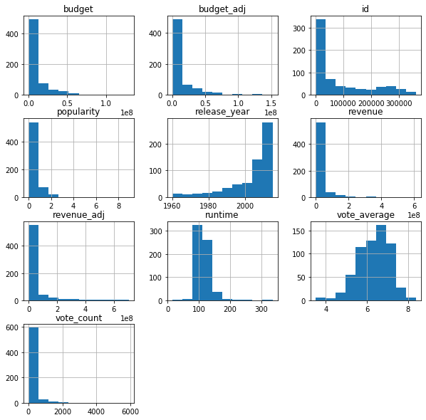

```python
df_Drema.hist(figsize=(10,10));
```

## 1. Profit trends of Drema movies

I have to calculate the profit and loss of the Movies and add that column in the dataset.

```python
df_Drema.insert(4,'Porfit_and_loss',df_Drema['revenue']  - df_Drema['budget'])
```

```python
df_Drema.info()
```

```
<class 'pandas.core.frame.DataFrame'>
Int64Index: 638 entries, 55 to 10824
Data columns (total 17 columns):
id                      638 non-null int64
popularity              638 non-null float64
budget                  638 non-null float64
revenue                 638 non-null float64
Porfit_and_loss         638 non-null float64
original_title          638 non-null object
cast                    638 non-null object
director                638 non-null object
runtime                 638 non-null int64
genres                  638 non-null object
production_companies    638 non-null object
release_date            638 non-null object
vote_count              638 non-null int64
vote_average            638 non-null float64
release_year            638 non-null int64
budget_adj              638 non-null float64
revenue_adj             638 non-null float64
dtypes: float64(7), int64(4), object(6)
memory usage: 89.7+ KB
```

This Graph shows the profit trends year wise for this trend i have used line char show this it will easy to understand.

```python
# i have taken variable name as graph and i'll pass this as a argument in my function which help me to ploting a graph.
graph=df_Drema.groupby('release_year')['Porfit_and_loss'].sum()
```

### I have written a function which help me to ploting a line graph and i have to make a line plot for two more analysis so it'll me to reuse this function again.

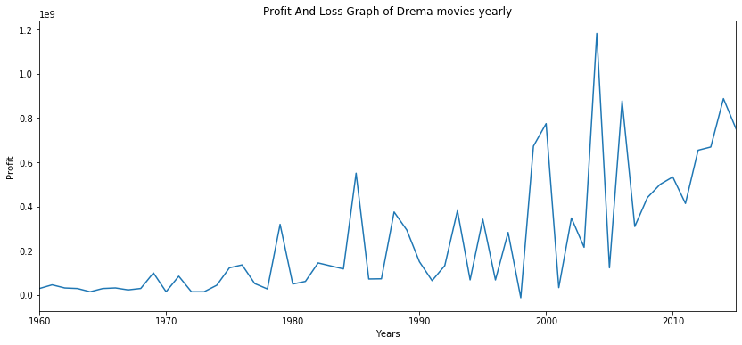

```python
def fig_fun(data,title,xlabel,ylabel):
    graph.plot(kind='line',figsize=(14,6))
    plt.title(title)
    plt.xlabel(xlabel)
    plt.ylabel(ylabel)

fig_fun(graph,title='Profit And Loss Graph of Drema movies yearly',xlabel='Years',ylabel='Profit')
```

In this graph i clearly saw that profit of the drema movie is increase with respect to the years.

## 2. Average Vote Given by the user to Drema Movies

For this analysis i have used line chart.

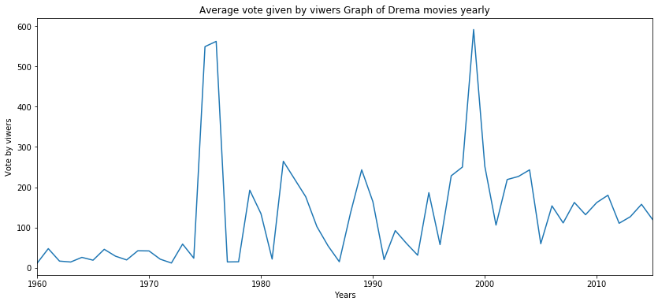

```python
graph=df_Drema.groupby('release_year')['vote_count'].mean()

fig_fun(graph,'Average vote given by viwers Graph of Drema movies yearly','Years','Vote by viwers')
```

## 3. Average Run Time of Drema Movies

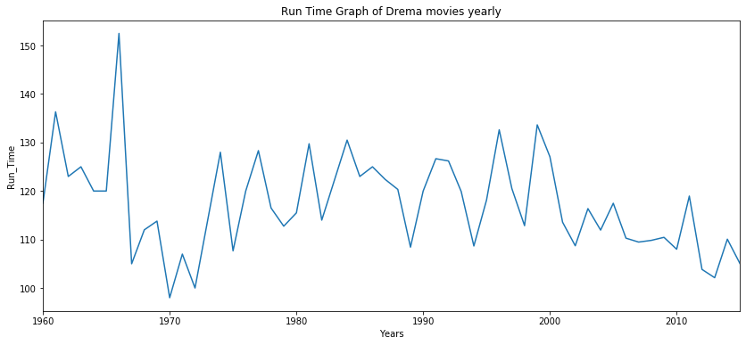

```python
graph=df_Drema.groupby('release_year')['runtime'].mean()

fig_fun(graph,'Run Time Graph of Drema movies yearly','Years','Run_Time')
```

Average Runtime of the Drema movies is nearly 2 hours.

## 4. Which variable effect the more in Drema movie

```python
df_Drema.corr()
```

|  | id | popularity | budget | revenue | Porfit_and_loss | runtime | vote_count | vote_average | release_year | budget_adj | revenue_adj |
| --- | --- | --- | --- | --- | --- | --- | --- | --- | --- | --- | --- |
| id | 1.000000 | -0.001850 | -0.190969 | -0.171401 | -0.133694 | -0.204636 | -0.077676 | -0.164798 | 0.559621 | -0.264646 | -0.219674 |
| popularity | -0.001850 | 1.000000 | 0.337234 | 0.446901 | 0.396256 | 0.177067 | 0.858320 | 0.303094 | 0.062545 | 0.371110 | 0.466770 |
| budget | -0.190969 | 0.337234 | 1.000000 | 0.487618 | 0.244857 | 0.305630 | 0.348405 | 0.111570 | 0.030790 | 0.914448 | 0.413469 |
| revenue | -0.171401 | 0.446901 | 0.487618 | 1.000000 | 0.965877 | 0.195418 | 0.526548 | 0.237744 | -0.074401 | 0.515360 | 0.904994 |
| Porfit_and_loss | -0.133694 | 0.396256 | 0.244857 | 0.965877 | 1.000000 | 0.126350 | 0.481391 | 0.230924 | -0.091759 | 0.301045 | 0.882367 |
| runtime | -0.204636 | 0.177067 | 0.305630 | 0.195418 | 0.126350 | 1.000000 | 0.172131 | 0.235700 | -0.219839 | 0.356106 | 0.202926 |
| vote_count | -0.077676 | 0.858320 | 0.348405 | 0.526548 | 0.481391 | 0.172131 | 1.000000 | 0.350660 | 0.029028 | 0.363852 | 0.500281 |
| vote_average | -0.164798 | 0.303094 | 0.111570 | 0.237744 | 0.230924 | 0.235700 | 0.350660 | 1.000000 | -0.106834 | 0.159954 | 0.264704 |
| release_year | 0.559621 | 0.062545 | 0.030790 | -0.074401 | -0.091759 | -0.219839 | 0.029028 | -0.106834 | 1.000000 | -0.105519 | -0.195386 |
| budget_adj | -0.264646 | 0.371110 | 0.914448 | 0.515360 | 0.301045 | 0.356106 | 0.363852 | 0.159954 | -0.105519 | 1.000000 | 0.517342 |
| revenue_adj | -0.219674 | 0.466770 | 0.413469 | 0.904994 | 0.882367 | 0.202926 | 0.500281 | 0.264704 | -0.195386 | 0.517342 | 1.000000 |

```python
df_Drema['Porfit_and_loss'].max()
```

```
581899420.0
```

```python
df_Drema.query('Porfit_and_loss>45000000').sort_values('budget',ascending=False).head(5)
```

|  | id | popularity | budget | revenue | Porfit_and_loss | original_title | cast | director | runtime | genres | production_companies | release_date | vote_count | vote_average | release_year | budget_adj | revenue_adj |
| --- | --- | --- | --- | --- | --- | --- | --- | --- | --- | --- | --- | --- | --- | --- | --- | --- | --- |
| 8730 | 2133 | 0.583320 | 120000000.0 | 325756637.0 | 205756637.0 | The Perfect Storm | George Clooney\|Mark Wahlberg\|Diane Lane\|John C... | Wolfgang Petersen | 130 | Drama | Warner Bros.\|Baltimore Spring Creek Production... | 3/15/00 | 315 | 5.9 | 2000 | 1.519551e+08 | 412503060.6 |
| 5013 | 2289 | 0.875248 | 79000000.0 | 173013509.0 | 94013509.0 | Cold Mountain | Jude Law\|Nicole Kidman\|Renée Zellweger\|Eileen... | Anthony Minghella | 154 | Drama | Miramax Films\|Mirage Enterprises\|Castel Film R... | 12/24/03 | 299 | 6.5 | 2003 | 9.364286e+07 | 205082020.5 |
| 6676 | 1125 | 0.647700 | 70000000.0 | 154937680.0 | 84937680.0 | Dreamgirls | Jamie Foxx\|Beyoncé Knowles\|Eddie Murphy\|Danny... | Bill Condon | 134 | Drama | Paramount Pictures\|DreamWorks SKG\|Laurence Mar... | 12/25/06 | 146 | 6.5 | 2006 | 7.571684e+07 | 167591309.9 |
| 2429 | 345 | 1.329827 | 65000000.0 | 162091208.0 | 97091208.0 | Eyes Wide Shut | Tom Cruise\|Nicole Kidman\|Madison Eginton\|Jacki... | Stanley Kubrick | 159 | Drama | Hobby Films\|Pole Star\|Stanley Kubrick Producti... | 7/14/99 | 623 | 6.8 | 1999 | 8.508844e+07 | 212185957.2 |
| 1973 | 38167 | 1.271623 | 60000000.0 | 204594016.0 | 144594016.0 | Eat Pray Love | Julia Roberts\|James Franco\|Javier Bardem\|Billy... | Ryan Murphy | 133 | Drama | Columbia Pictures\|Red Om Films\|Plan B Entertai... | 08-12-2010 | 407 | 5.7 | 2010 | 6.000000e+07 | 204594016.0 |